# p8105_hm1_xl3371

Xuer Liu

2023-09-20

```r
library(tidyverse) #load packages
library(moderndive)
data("early_january_weather")
```

# Problem 1

## Description of the dataset

The dataset “early_january_weather” contains 15 variables which are origin, year, month, day, hour, temp, dewp, humid, wind_dir, wind_speed, wind_gust, precip, pressure, visib, time_hour.

Some importants variables are “temp”and “humid”.

For variable “temp”, the mean value is 39.5821229 and standard deviation (SD) is 7.058637.

For variable “humid”, the mean value is 65.4767039 and SD is 18.9453049.

The dataset consists of 358 rows and 15 columns.

The mean temperature is 39.5821229 degrees.

## Create a scatterplot

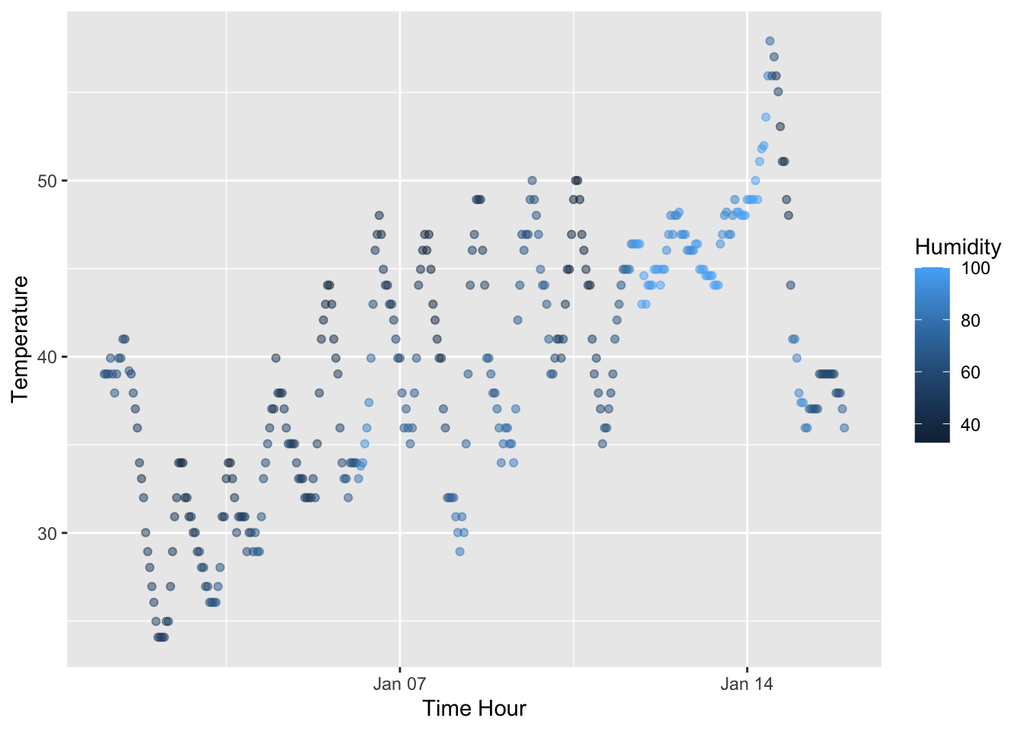

```r
plot <- early_january_weather %>% ggplot(aes(x=time_hour, y=temp, color=humid)) +
  geom_point(alpha=0.5) +
  labs(x="Time Hour",
       y="Temperature",
       color="Humidity")
print(plot)
```

```r
ggsave("plot.png")
```

# Problem 2

## Create a data frame

```r
df <- tibble(
  numeric_vector = rnorm(10),
  logic_vector = numeric_vector > 0,
  character_vector = c("a", "b", "c", "d", "e", "f", "g", "h", "i", "j"),
  factor_vector = factor(c("medium", "mild", "hot", "medium", "mild", "hot", "medium", "mild", "hot", "medium"))
)
```

## Take the mean of each variable

```r
mean(df %>% pull(numeric_vector)) #work
```

```
## [1] 0.08844042
```

```r
mean(df %>% pull(logic_vector)) #work
```

```
## [1] 0.6
```

```r
mean(df %>% pull(character_vector)) #return NA
```

```
## [1] NA
```

```r
mean(df %>% pull(factor_vector)) #return NA
```

```
## [1] NA
```

We could successfully take the mean of numeric and logical variables; however, we are not able to take the mean of character and factor variables.

## Convert variables

```r
as.numeric(df %>% pull(logic_vector))
as.numeric(df %>% pull(character_vector))
as.numeric(df %>% pull(factor_vector))
```

[output not shown]

When converting the factor vector to numeric vector, the output is 1, 2,and 3, since we only have 3 different factor “levels”. Rstudio automatically assign different factor levels with integer codes, and the mean of the integer codes does not equate to the mean of the original data. Thus, we are not able to take the mean of factor vector.

As for character vector, we are not able to convert it to a numeric vector, it returns NA since there is no numeric value, which explains why we cannot take the mean of character vector since it is meaningless to calculate the mean of non-numeric stings.